# Modelling workshop: Session 8

##### Example 2

Now let’s look as some disease data. These were taken from a very useful resource, https://epirhandbook.com/en/index.html

The time series data and some of this code came directly from their time series analysis section here: https://epirhandbook.com/en/time-series-and-outbreak-detection.html

We can install the entire package by following this code using the **pacman** library, but I have commented it out here because it takes ages!

```r
# install the latest version of the Epi R Handbook package
library(pacman)
#pacman::p_install_gh("appliedepi/epirhandbook")
```

Then we can load the package for use:

```r
# load the package for use
# pacman::p_load(epirhandbook)
```

This is the way that this group loads their packages using the **p_load** function in the **pacman** package.

```r
library(pacman)

pacman::p_load(rio,          # File import
               here,         # File locator
               tidyverse,    # data management + ggplot2 graphics
               tsibble,      # handle time series datasets
               slider,       # for calculating moving averages
               imputeTS,     # for filling in missing values
               feasts,       # for time series decomposition and autocorrelation
               forecast,     # fit sin and cosin terms to data (note: must load after feasts)
               trending,     # fit and assess models
               yardstick,    # for looking at model accuracy
               surveillance  # for aberration detection
               )
```

Now let’s import the data. Note that this data is available from the *epirhandbook* website, but it is already included in the data files for this workshop. These data are counts of campylobacteriosis cases from Germany.

```r
counts <- rio::import("data/campylobacter_germany.xlsx")
```

Note that the above takes some time, so the below code might be a quicker ways to load, but you will need some of the packages above too. It’s commented out for now.

```r
#install.packages("readxl", dependencies = T)
#library(readxl)
#library(tidyverse)
#library(dplyr)
#library(tsibble)
#library(imputeTS)
#library(slider)
# read_excel reads both xls and xlsx files
#counts <- as.data.frame(read_excel("data/campylobacter_germany.xlsx"))
```

Next we reformat the date column and organise the dates into weeks:

```r
## ensure the date column is in the appropriate format
counts$date <- as.Date(counts$date)

## create a calendar week variable
## fitting ISO definitons of weeks starting on a monday
counts <- counts %>%
     mutate(epiweek = yearweek(date, week_start = 1))
```

Then we can plot the data:

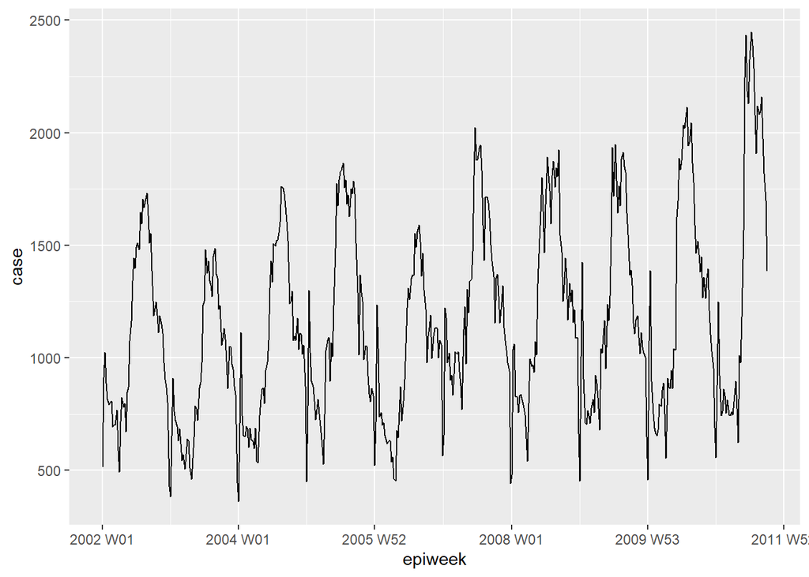

```r
## plot a line graph of cases by week
ggplot(counts, aes(x = epiweek, y = case)) +
     geom_line()
```

Next we can **interpolate** missing data into data sets using this code to do linear interpolation between data:

```r
## create a variable with missing data instead of weeks with reporting issues
counts <- counts %>%
     mutate(case_miss = if_else(
          ## if epiweek contains 52, 53, 1 or 2
          str_detect(epiweek, "W51|W52|W53|W01|W02"),
          ## then set to missing
          NA_real_,
          ## otherwise keep the value in case
          case
     ))

## alternatively interpolate missing data by linear trend
## between two nearest adjacent points
counts <- counts %>%
  mutate(case_int = imputeTS::na_interpolation(case_miss)
         )
```

Let’s plot those:

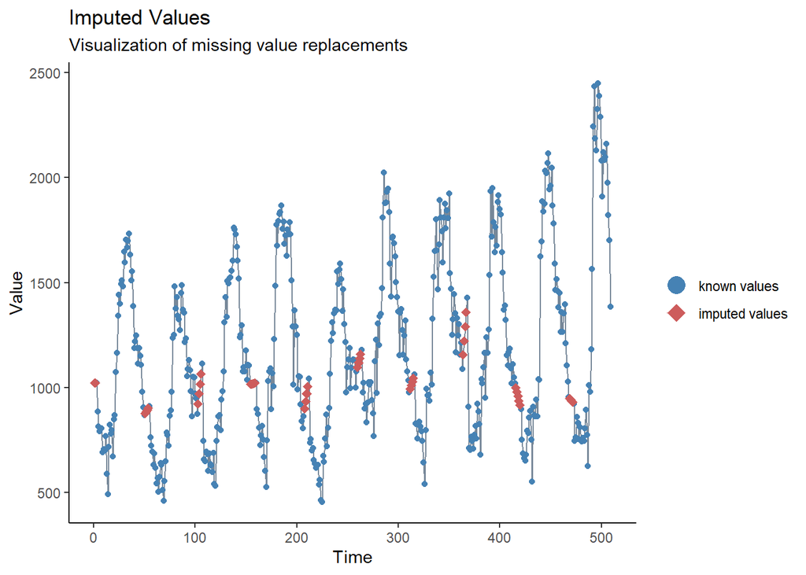

```r
## to check what values have been imputed compared to the original
ggplot_na_imputations(counts$case_miss, counts$case_int) +
  ## make a traditional plot (with black axes and white background)
  theme_classic()
```

Next we can use a moving average to do a similar job:

```r
## create a moving average variable (deals with missing data)
counts <- counts %>%
     ## create the ma_4w variable
     ## slide over each row of the case variable
     mutate(ma_4wk = slider::slide_dbl(case,
                               ## for each row calculate the name
                               ~ mean(.x, na.rm = TRUE),
                               ## use the four previous weeks
                               .before = 4))
```

Here is what the difference between those approaches looks like when we plot the moving average on top of the cases:

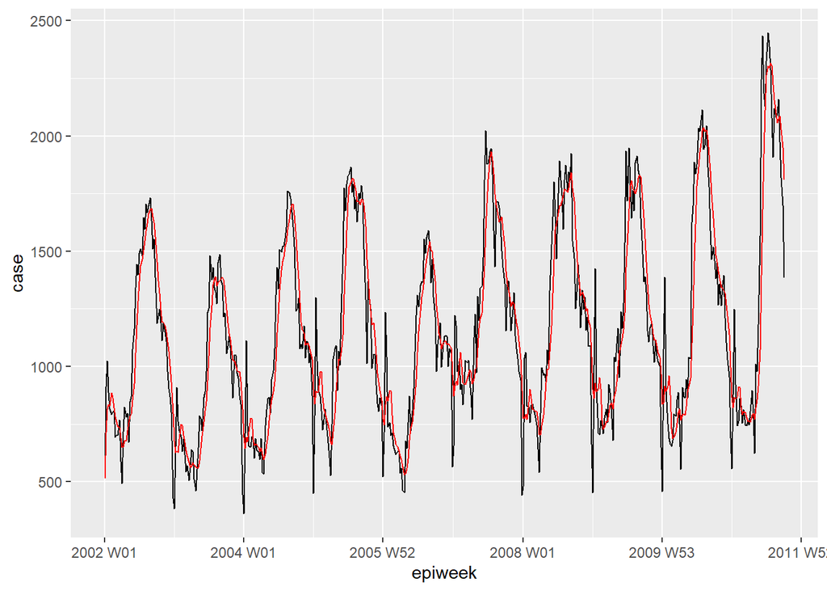

```r
## make a quick visualisation of the difference
ggplot(counts, aes(x = epiweek)) +
     geom_line(aes(y = case)) +
     geom_line(aes(y = ma_4wk), colour = "red")
```

Next, let’s do a **decomposition** on those cases using another function, **STL()** similar to the **decompose()** function above and plot it directly using the **autoplot()** function:

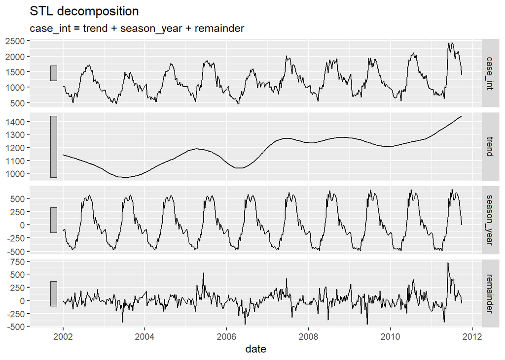

```r
counts %>%
  as_tsibble(., index = date) %>%
  model(STL(case_int, robust = TRUE)) %>%
  components() %>%
  autoplot()
```

Have a think about the above data.

**Autocorrelation** is the correlation between two observations at different points in a time series. For example, samples taken close together in time might have a strong *positive* or *negative* **correlation**. When these correlations are present, they indicate that past values influence the current value. **Autocorrelation** and **partial autocorrelation** functions allow us to see this and understand the properties of time series data, fit the appropriate models, and make forecasts.

We talk about these correlations using the term **lags**, which in time-series data by are the characteristic, **evenly spaced intervals**, such as *days*, *months*, or *years*. The number of intervals between the two observations is the lag.

Let’s look at **autocorrelation** using the **ACF()** function:

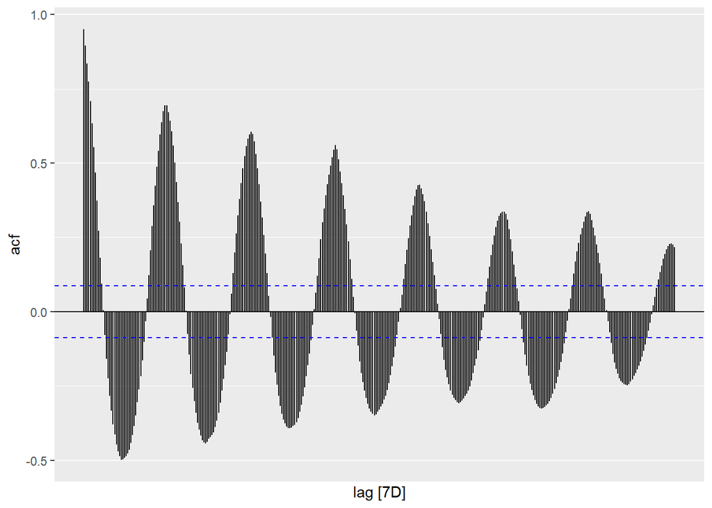

```r
## using the counts dataset
counts %>% as_tsibble(., index = date) %>%
  ## calculate autocorrelation using a full years worth of lags
  ACF(case_int, lag_max = 365) %>%
  ## show a plot
  autoplot()
```

We can see that the data are strongly autocorrelated. But what about the **partial autocorrelation** analysis. Let’s do that using the **PACF()** function:

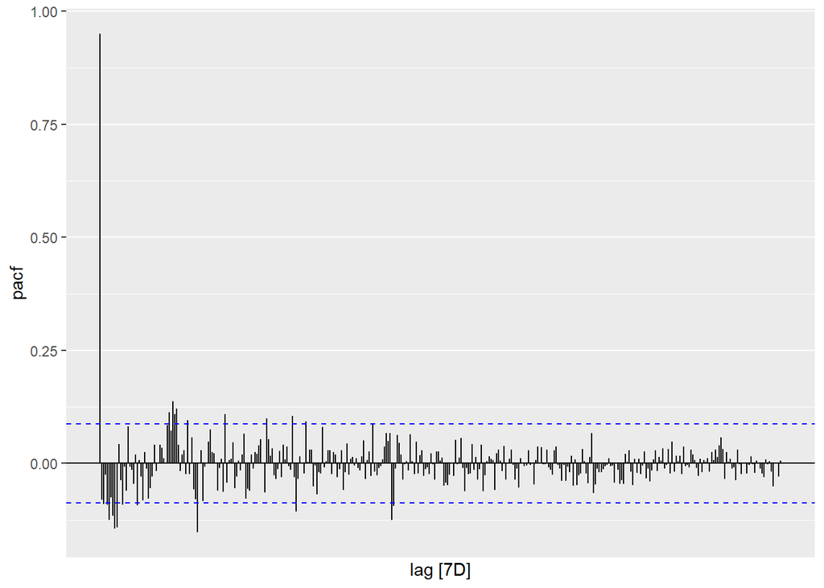

```r
## using the counts data set
counts %>% as_tsibble(., index = date) %>%
  ## calculate the partial autocorrelation using a full years worth of lags
  PACF(case_int, lag_max = 365) %>%
  ## show a plot
  autoplot()
```

The **PACF** results look very different. This is because partial autocorrelation is the relationship between an observation in a time series with observations at prior time steps with the relationships of intervening observations removed. PACF results are harder to interpret sometimes, and here there is a significant correlation at lag 1 followed by correlations that are not significant and some that are (indicated by being over the dashed lines).

We can see that these data are **not independent**, and we can test for that using the Ljung–Box test statistic (sometimes called the *‘portmanteau’* test) for examining the null hypothesis of independence in a given time series.

```r
## test for independence
Box.test(counts$case_int, type = "Ljung-Box")
```

```
##
##  Box-Ljung test
##
## data:  counts$case_int
## X-squared = 462.65, df = 1, p-value < 2.2e-16
```

### Session 8c - Introduction to Plotting Phylogenetic Trees in R

Phylogenetics trees *can* but do not all include information on time.

**Phylogenetic analysis** studies the evolutionary relationships between organisms. It involves constructing phylogenetic trees or evolutionary trees that illustrate the evolutionary history and relatedness of different species, populations, or genes.

The primary goal of phylogenetic analysis is to understand how species have evolved and diverged from common ancestors over time. In any analysis the assumption is that all the organisms’ sequence data share a common ancestor and have diversified through evolution.

Various methods and algorithms have been developed for phylogenetic analysis, including **distance-based methods**, which is new, **maximum likelihood** methods, and **Bayesian inference**, which we have already met. These methods utilize statistical models and computational techniques to compare and evaluate the evolutionary relationships among organisms and estimate the most likely phylogenetic tree.

Phylogenetic analyses involve several key steps: * sample collection * nucleotide (RNA or DNA) extraction * nucleotide sequencing * sequence assembly * sequence alignment * evolutionary and phylogenetic modelling

There are many ways of doing the above. Here we will assume these are all done and sequence alignments have been performed by any number of tools (e.g. from here https://www.ebi.ac.uk/Tools/msa/) and that the phylogenetic analyses have been performed (e.g. using BEAST here https://beast.community/).

Here we will import a **newick** file that has a tree in that has already been downloaded and is in the github respository for this workshop from https://4va.github.io/biodatasci/data.html

We will be using examples from https://yulab-smu.top/treedata-book/

```r
library(tidyverse)
library(devtools)
# devtools::install_github("YuLab-SMU/treeio")
library(tidyverse)
if (!require("BiocManager", quietly = TRUE))
    install.packages("BiocManager")
BiocManager::install("ggtree")
library(ggtree)
require(treeio)
tree <- read.tree("data/tree_newick.nwk")
tree
```

```
##
## Phylogenetic tree with 13 tips and 12 internal nodes.
##
## Tip labels:
##   A, B, C, D, E, F, ...
##
## Rooted; includes branch lengths.
```

Next we plot the tree:

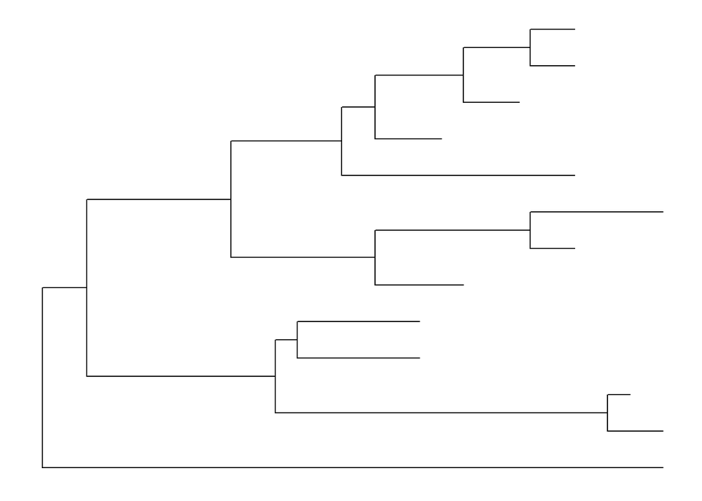

```r
ggplot(tree) + geom_tree() + theme_tree()
```

Or with a scale:

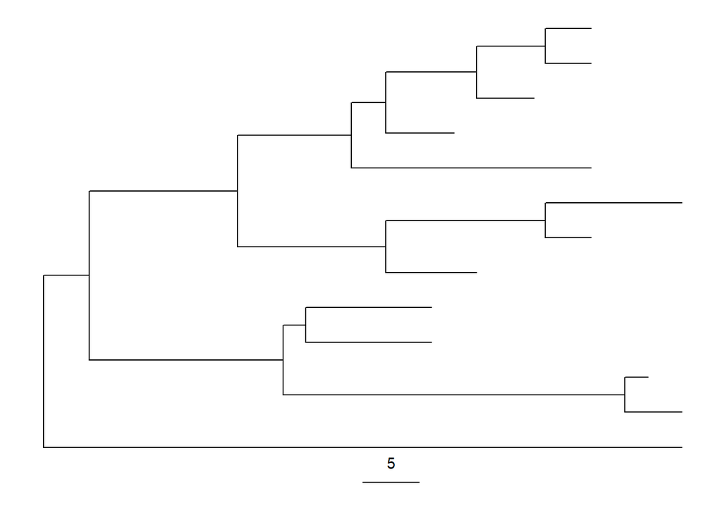

```r
ggtree(tree) + geom_treescale()
```

Or we plot it like this:

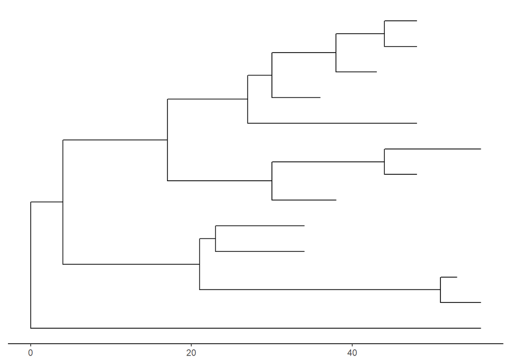

```r
# or add the entire scale to the x axis with theme_tree2()
ggtree(tree) + theme_tree2()
```

We can disable the scaling and produce a **cladogram** instead using **branch.length=“none”** inside the **ggtree()** function call.

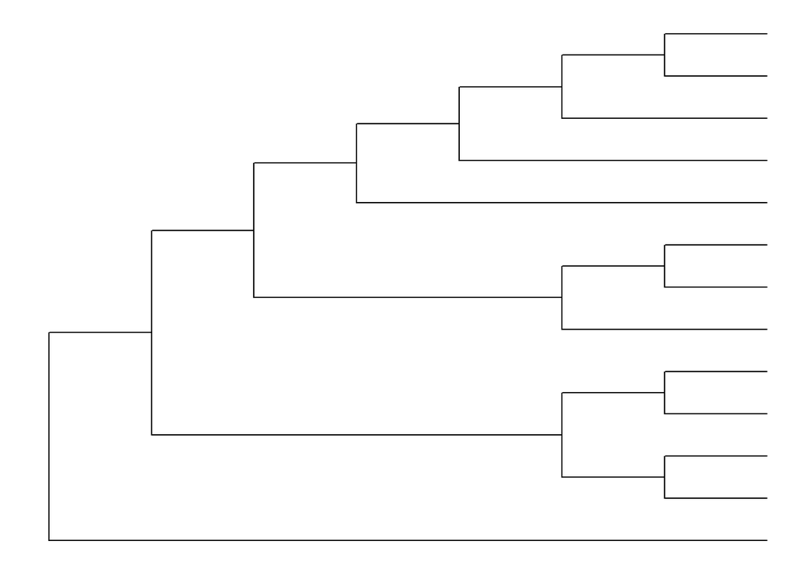

```r
ggtree(tree, branch.length="none")
```

Note that cladograms have no information shown about time. The **branch lengths** are not meaningful here.

Next we can plot the tree and highlight clades of interest:

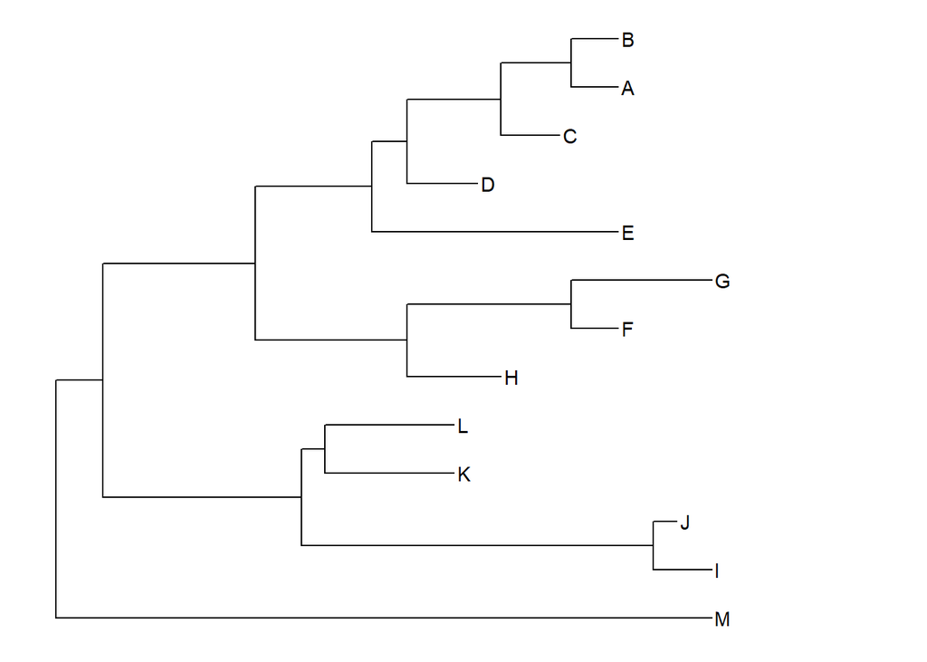

```r
ggtree(tree) +
  geom_tiplab() +
  geom_cladelabel(node=17, label="clade A",
                  color="red2", offset=.8, align=TRUE) +
  geom_cladelabel(node=21, label="clade B",
                  color="blue", offset=.8, align=TRUE) +
  theme_tree2() +
  xlim(0, 70) +
  theme_tree()
```

Or highlight clades by choosing a node:

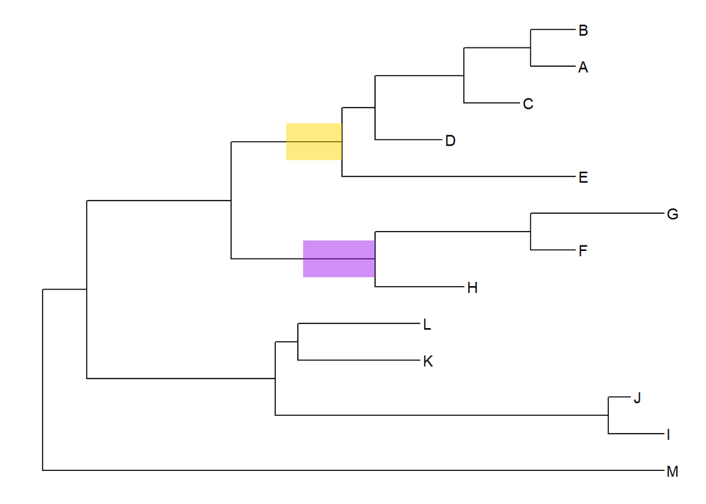

```r
ggtree(tree) +
  geom_tiplab() +
  geom_hilight(node=17, fill="gold") +
  geom_hilight(node=21, fill="purple")
```

Or we can link taxa:

```
## taxa1 and taxa2 is not in the 1st and 2nd positions of the parameter list.
## Please specify parameter name in future as this backward compatibility will be removed.
##
## taxa1 and taxa2 is not in the 1st and 2nd positions of the parameter list.
## Please specify parameter name in future as this backward compatibility will be removed.
```

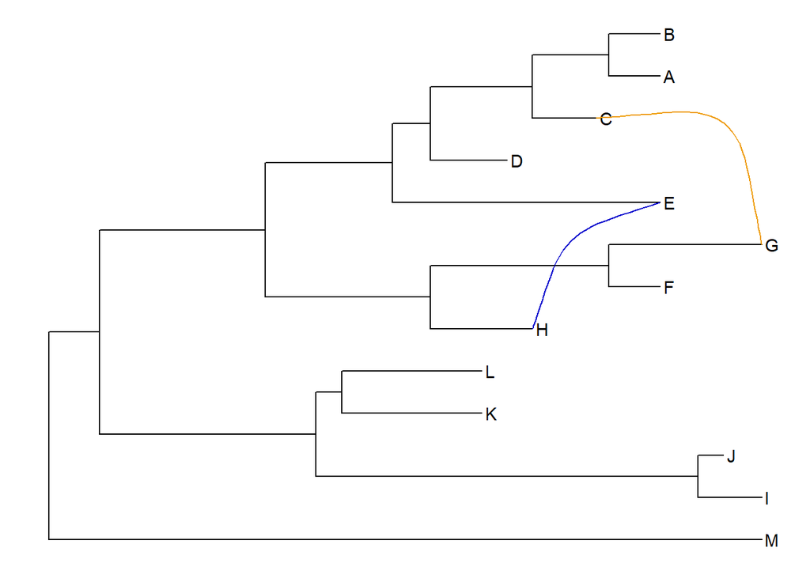

```r
ggtree(tree) +
  geom_tiplab() +
  geom_taxalink("E", "H", color="blue3") +
  geom_taxalink("C", "G", color="orange2", curvature=-.9)
```

Next we can import and plot some infection related data. Here we will use the data from *Liang et al. “Expansion of genotypic diversity and establishment of 2009 H1N1 pandemic-origin internal genes in pigs in China.” Journal of virology (2014): 88(18):10864-74.*

This data set has been analysed in BEAST and so has time related data.

```r
# Import the data.
require(ggtree)
tree <- read.beast("data/flu_tree_beast.tree")
```

Next we plot it by providing the most recent sampling date so we get the dates and can add a scale bar like this:

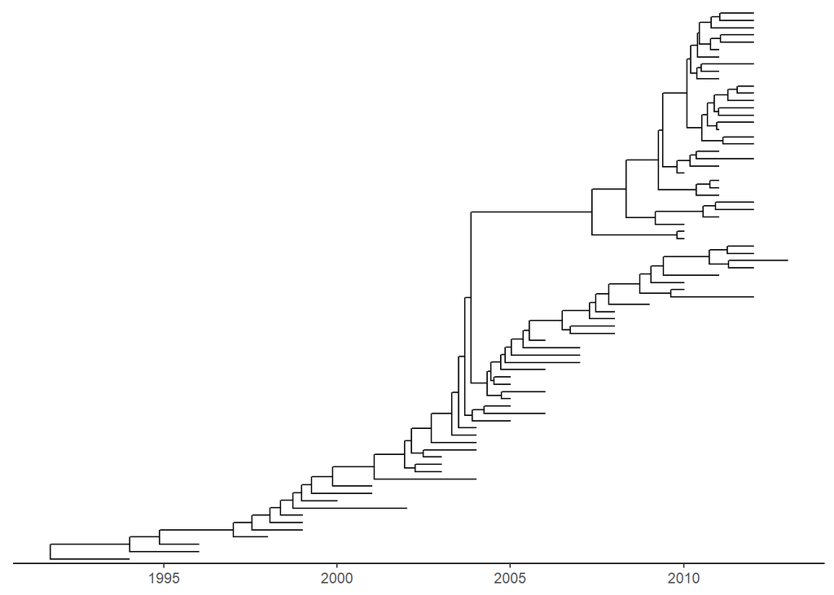

```r
ggtree(tree, mrsd="2013-01-01") +
  theme_tree2()
```

And finally we can add tip labels and adjust the axis

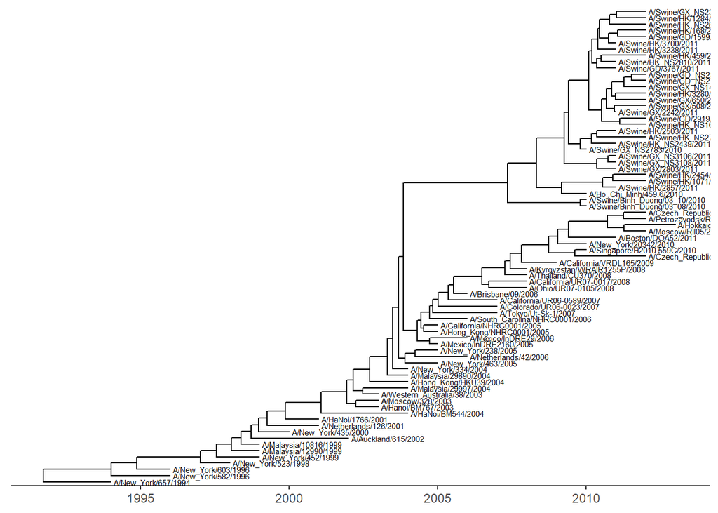

```r
ggtree(tree, mrsd="2013-01-01") +
  theme_tree2() +
  geom_tiplab(size=2, align = F)
```

We covered a lot of material is a short time during this workshop. This is meant to simply get you started. Enjoy. ### The END